# 03-ANOVA

Robert C Cline Sr

2022-04-15

#### ANOVA is a linear regression on a continuous response variable (Karen Grace-Martin, 2009).[^1]

We just did with the apples in *01-LinearModels.Rmd*. How does the mean yield vary depending on the spacing category?

It is also a linear model, but instead of getting a slope that allows us to predict the yield for any value of spacing, we get an estimate of the yield for each category.

#### ANOVA

We just did with the apples in *01-LinearModels.Rmd*: how does the mean yield vary depending on the spacing category?

ANOVA is also a linear model, but *instead of getting a slope* that allows us to predict the yield for any value of spacing, *we get an estimate of the yield* for each category. In the ANOVA, the categorical variable is *effect coded*.[^2]

#### ANOVA vs. REGRESSION

- The same model but reported in different ways:

**In ANOVA**, means are reported and a p-value for each group.  
**In Regression**, reports only one mean (the intercept) and differences of the other means; and the coefficients for intercept and slope are reported.

**Effect coding** Categories are coded with (1, -1). This means that each category’s mean is compared to the grand mean.

**Dummy coding** – In regression, which means that each category’s intercept is compared to the reference group‘s intercept. Since the intercept is defined as the mean value when all other predictors = 0, and there are no other predictors, the three intercepts are just means.

1. The coefficients reflect actual cell mean differences and have meaningful interpretations as such.
2. When there is an interaction, the value of b1, eg, is the effect of X1 when X2=0. Since X2=0 for one category of X2, b12 is not a main effect (an overall effect of X1 across all values of X2). It’s a marginal effect: an effect of X1 at a signle value of X2.

```
## Analysis of Variance Table
##
## Response: yield
##           Df Sum Sq Mean Sq F value    Pr(>F)
## spacing2   2  35801 17900.3  9.3851 0.0002003 ***
## Residuals 89 169750  1907.3
## ---
## Signif. codes:  0 '***' 0.001 '**' 0.01 '*' 0.05 '.' 0.1 ' ' 1
```

### Checking the assumptions.

1. Are the residuals normally distributed?
2. Are the data homoscedastic (i.e. the variance being the same around all variables)?
3. Are the observations independent?

```
##
##  Shapiro-Wilk normality test
##
## data:  apples.resid
## W = 0.99224, p-value = 0.8723
```

```
##
##  Bartlett test of homogeneity of variances
##
## data:  apples$yield and apples$spacing2
## Bartlett's K-squared = 3.9843, df = 2, p-value = 0.1364
```

```
##
##  Bartlett test of homogeneity of variances
##
## data:  yield by spacing2
## Bartlett's K-squared = 3.9843, df = 2, p-value = 0.1364
```

If the reisuals are not normally distributred or data are heteroscedastic, you can consider transforming your data using a logarithmic transformation of square root transformation.

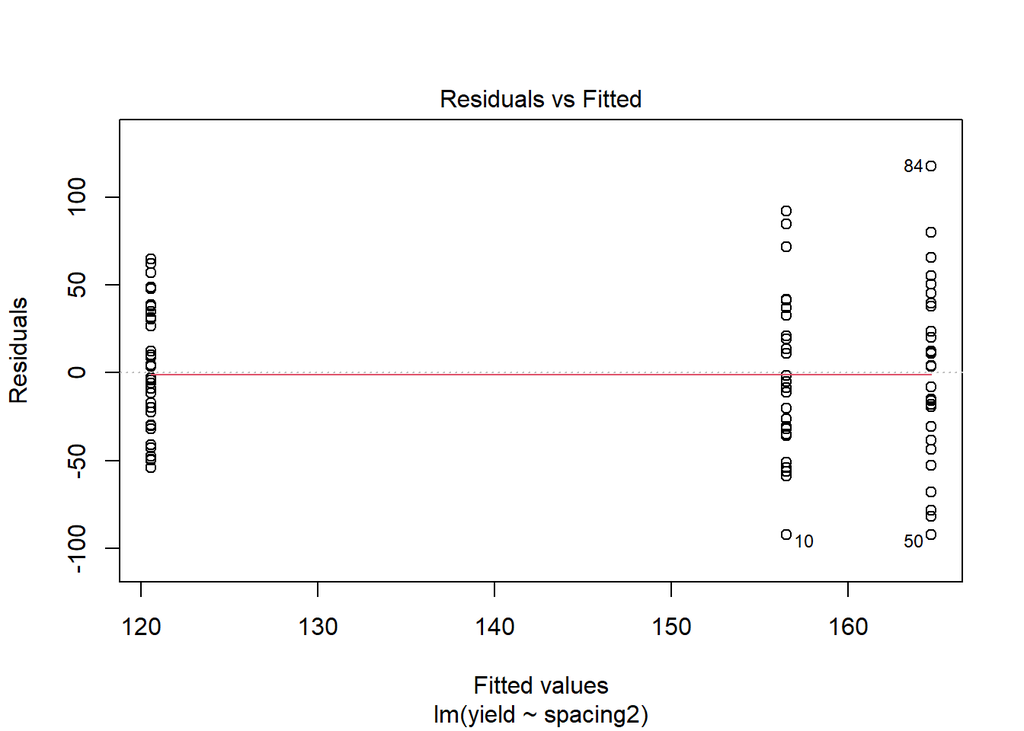

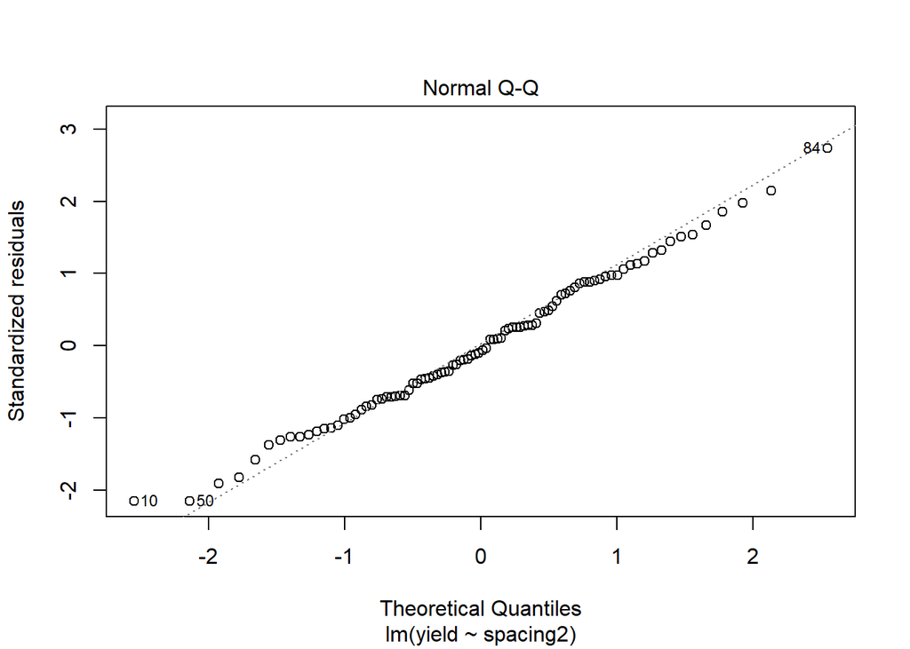

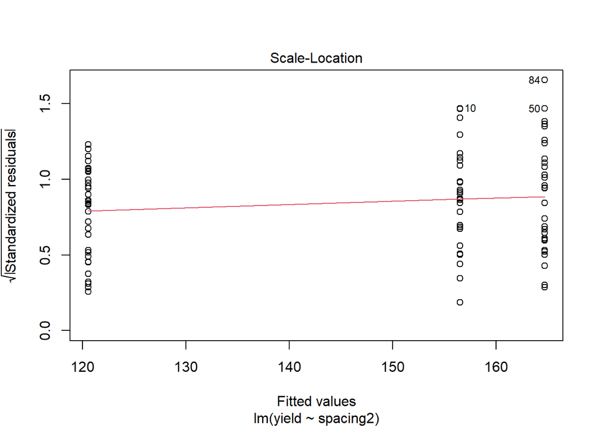

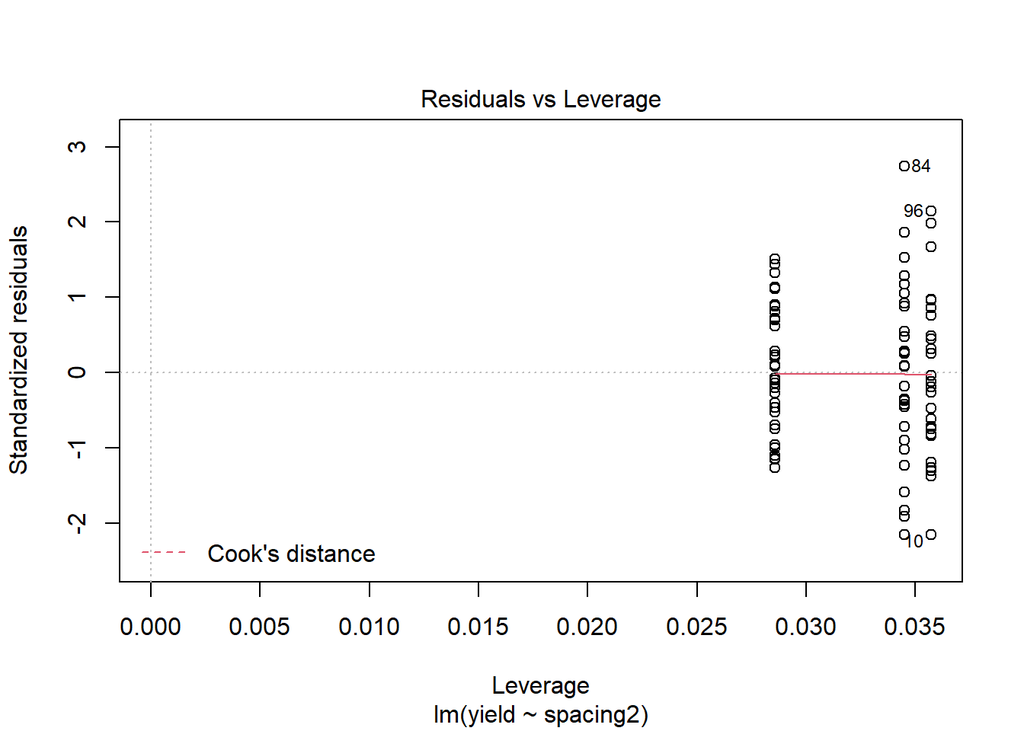

[Understanding Diagnostic Plots for Linear Regression Models](https://data.library.virginia.edu/diagnostic-plots/)[^3]

[^1]: Why ANOVA and Linear Regression are the Same Analysis. (2009, March 11). The Analysis Factor. https://www.theanalysisfactor.com/why-anova-and-linear-regression-are-the-same-analysis/
[^2]: Interpreting Interactions Between Two Effect-Coded Categorical Predictors. (2011, October 21). The Analysis Factor. https://www.theanalysisfactor.com/interactions-effect-coded-predictors/
[^3]: Understanding Diagnostic Plots for Linear Regression Analysis | University of Virginia Library Research Data Services + Sciences. (n.d.). Retrieved April 15, 2022, from https://data.library.virginia.edu/diagnostic-plots/